# Urban Circulators and Home Values: A Revisited Difference-in-Differences Analysis

Extending a 2023 undergraduate paper with panel fixed effects, clustered standard errors, and an event-study design

Author

Quin Rizer

Published

September 21, 2026

## Background

In 2023 I wrote a paper (`Final Paper.docx` / `regression.R` in this repository) asking whether St. Louis’s Delmar Loop Trolley raised home values in the zip codes it runs through (63130, 63112), relative to three comparison zips (63114, 63133, 63108) chosen for similar geography and demographics. That analysis ran a separate `lm(HomeValue ~ time + treated + did)` for each of several candidate treatment dates (announcement in 2010, construction start in 2015, opening in 2018) and found no statistically significant increase in home values under any plausible treatment date – the one specification that *did* come back significant relied on a 20-year window and was flagged in the paper itself as likely confounded by unrelated City/County policy differences over that span.

This notebook revisits that question two ways:

1. **An improved version of the original St. Louis model** – same treated/comparison zips, same preferred treatment date (the trolley’s actual opening, since that’s the least ambiguous and least confounded of the three candidate dates), but with two changes standard in applied DiD work that the original didn’t have: zip and time fixed effects instead of simple dummy variables, and standard errors clustered by zip (monthly home values within a zip are highly autocorrelated, so un-clustered OLS standard errors understate uncertainty).
2. **A pooled model across all three circulators** this project now covers – St. Louis, the KC Streetcar, and the Cincinnati Connector – to ask the broader question the single-city design can’t: do urban circulators raise home values *in general*, not just in one city.

A caveat up front: part 2’s comparison zips for Kansas City and Cincinnati have not been vetted with anything like the care the original paper put into its St. Louis control group. That vetting is addressed below, but it’s a quick, county-level check – not a demographic or geographic argument on the level of the original paper. Part 2’s results should be read with that in mind.

```r
library(tidyverse)
library(fixest)
library(broom)
library(scales)

zip_data_raw <- read_csv("zip_data.csv", show_col_types = FALSE)
```

## Building an event-time panel

Each city’s circulator opened on a different calendar date, so pooling them requires a shared clock: *event time*, measured in months relative to that city’s own opening date, rather than calendar time. `build_event_panel()` below takes a city’s treated and comparison zips and its opening date, reshapes the wide Zillow export into zip-month rows, computes each row’s distance from the opening date in months, and restricts the panel to a fixed window on either side of it.

```r
build_event_panel <- function(zip_data, treated_zips, comparison_zips, opening_date,
                               window_months = 36, city_label) {
  zips <- c(treated_zips, comparison_zips)
  date_cols <- zip_data %>%
    select(matches("^\\d{4}-\\d{2}-\\d{2}$")) %>%
    names()
  opening_date <- as.Date(opening_date)

  zip_data %>%
    filter(RegionName %in% zips) %>%
    select(RegionName, City, CountyName, all_of(date_cols)) %>%
    pivot_longer(cols = all_of(date_cols), names_to = "date_str", values_to = "HomeValue") %>%
    mutate(
      Date = as.Date(date_str),
      RegionName = as.character(RegionName),
      treated = as.integer(RegionName %in% treated_zips),
      # Whole-month distance from the opening date -- simple integer
      # arithmetic on year/month rather than lubridate period math, which
      # is more predictable across month-end dates like these.
      event_month = (year(Date) - year(opening_date)) * 12 +
        (month(Date) - month(opening_date))
    ) %>%
    filter(abs(event_month) <= window_months, !is.na(HomeValue)) %>%
    mutate(post = as.integer(event_month >= 0), city = city_label)
}
```

## Part 1: St. Louis, revisited

Treated zips (63130, 63112) and comparison zips (63114, 63133, 63108) match my original paper exactly – these are also the correct zips going forward for this project; the dashboard’s `stl_trend_zips` previously had a transcription typo (63113 instead of 63114) which has been fixed to match. Window: 36 months on either side of the November 2018 opening, matching the paper’s own preferred specification.

```r
stl_treated <- c("63130", "63112")
stl_comparison <- c("63114", "63133", "63108")

stl_panel <- build_event_panel(
  zip_data_raw, stl_treated, stl_comparison,
  opening_date = "2018-11-30", window_months = 36, city_label = "St. Louis"
)
```

### Two-way fixed-effects DiD

```r
stl_fe <- feols(HomeValue ~ treated:post | RegionName + Date, cluster = ~RegionName, data = stl_panel)
etable(stl_fe)
```

```
                           stl_fe
Dependent Var.:         HomeValue

treated x post  1,463.1 (6,508.4)
Fixed-Effects:  -----------------
RegionName                    Yes
Date                          Yes
_______________ _________________
S.E.: Clustered    by: RegionName
Observations                  365
R2                        0.99783
Within R2                 0.00756
---
Signif. codes: 0 '***' 0.001 '**' 0.01 '*' 0.05 '.' 0.1 ' ' 1
```

Zip fixed effects absorb each zip’s own baseline home value; date fixed effects absorb whatever was happening to home values region-wide (or nationally) in a given month. `treated:post` is the DiD estimate itself, and standard errors are clustered by zip – unlike the original `lm()`, which had neither.

### Event study: does parallel trends actually hold?

The original paper checked parallel trends by eye (“it seems visually that…”). This estimates a separate treated-vs-comparison gap for every month relative to the opening (holding the month right before opening, `event_month = -1`, as the reference), so pre-trends can be read off the plot directly instead of inferred from a line chart.

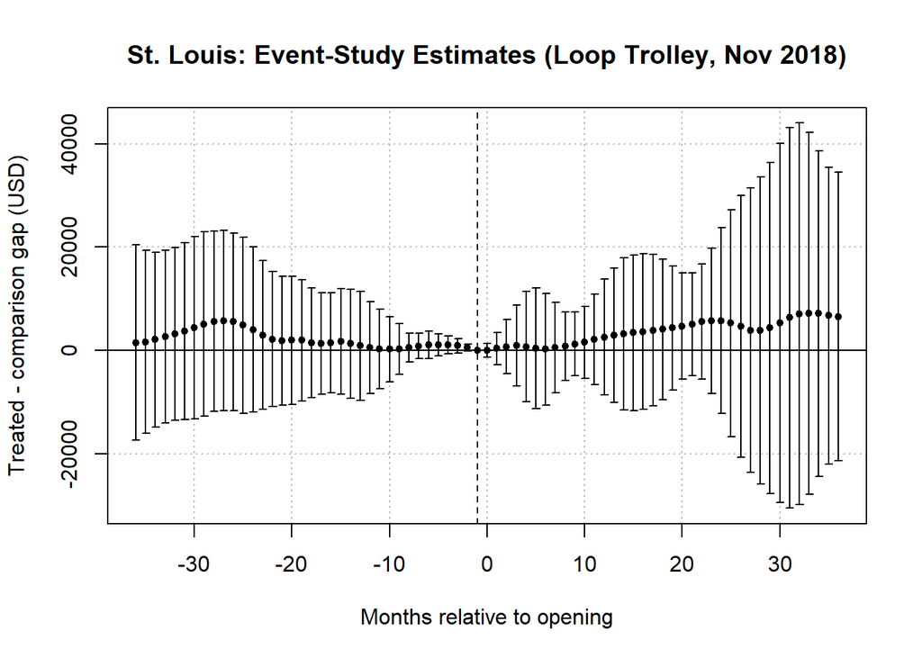

```r
stl_es <- feols(HomeValue ~ i(event_month, treated, ref = -1) | RegionName + Date,
                 cluster = ~RegionName, data = stl_panel)
iplot(stl_es,
      main = "St. Louis: Event-Study Estimates (Loop Trolley, Nov 2018)",
      xlab = "Months relative to opening", ylab = "Treated - comparison gap (USD)")
```

If the pre-period (negative `event_month`) coefficients sit close to zero with confidence intervals that comfortably span it, that’s real evidence for parallel trends – not just a visual impression. If they don’t, that’s worth reporting honestly rather than dropping the check.

## Part 2: Pooling all three circulators

### A quick vetting pass on the comparison zips

St. Louis’s comparison zips were chosen in the original paper for matching geography and demographics, with an explicit check that the group balances City vs. County jurisdiction against the treated pair. Kansas City’s and Cincinnati’s comparison zips, by contrast, were originally picked for the project’s dashboard trend chart – a visual choice, not an econometric one. A light check against each zip’s `City`/`CountyName` fields:

- **Kansas City** treated zips (64106, 64108, 64105) are all Jackson County. The dashboard’s original comparison list included 64116, which is Clay County – a different jurisdiction, exactly the kind of confound the original paper flagged for its own invalid long-window model. Swapped for **64111** (Westport / Country Club Plaza), which is Jackson County and, like the original paper’s choice of the Central West End (63108) in St. Louis, is a walkable/mixed-use district that was *not* served by the streetcar – the same logic, applied to Kansas City.
- **Cincinnati** treated zip (45202) and comparison zips (45203, 45212, 45219, 45206) are all Hamilton County. 45212 is technically Norwood, a separate incorporated city within the county, not Cincinnati proper – a milder version of the same issue, and one I’m choosing to leave as a disclosed limitation rather than resolve here.

This is not the level of scrutiny the original St. Louis group received. Treat Part 2 as a useful extension, not a replacement for Part 1.

```r
kc_treated <- c("64106", "64108", "64105")
kc_comparison <- c("64111", "64124", "64127") # 64116 (Clay County) swapped for 64111 (Jackson County)

cincy_treated <- c("45202")
cincy_comparison <- c("45203", "45212", "45219", "45206")

kc_panel <- build_event_panel(
  zip_data_raw, kc_treated, kc_comparison,
  opening_date = "2016-05-31", window_months = 36, city_label = "Kansas City"
)
cincy_panel <- build_event_panel(
  zip_data_raw, cincy_treated, cincy_comparison,
  opening_date = "2016-09-30", window_months = 36, city_label = "Cincinnati"
)

# Each city's treated/comparison zips are entirely distinct from the other
# cities' (no physical zip code appears in more than one city's panel), so
# stacking these three is simpler than the general "stacked DiD" literature
# deals with -- there's no shared pool of potential comparison units being
# reused across cohorts with different treatment timing, which is the
# problem that design was built to solve. Here it's just three independent
# local comparisons pooled into one regression for power, sharing an
# event-time clock instead of a calendar-time one.
pooled_panel <- bind_rows(stl_panel, kc_panel, cincy_panel) %>%
  mutate(
    zip_id = paste(city, RegionName, sep = "_"), # zip codes don't collide across these states, but this keeps the clustering unit unambiguous
    city = factor(city)
  )
```

### Pooled two-way fixed-effects DiD

`city^event_month` creates one fixed effect per (city, event-month) combination – the pooled equivalent of the date fixed effect in Part 1, since the three cities aren’t on the same calendar clock.

```r
pooled_fe <- feols(HomeValue ~ treated:post | zip_id + city^event_month,
                    cluster = ~zip_id, data = pooled_panel)
etable(stl_fe, pooled_fe, headers = c("St. Louis only", "Pooled (3 cities)"))
```

```
                            stl_fe         pooled_fe
                    St. Louis only Pooled (3 cities)
Dependent Var.:          HomeValue         HomeValue

treated x post   1,463.1 (6,508.4) 9,734.9 (6,493.7)
Fixed-Effects:   ----------------- -----------------
RegionName                     Yes                No
Date                           Yes                No
zip_id                          No               Yes
city-event_month                No               Yes
________________ _________________ _________________
S.E.: Clustered     by: RegionName        by: zip_id
Observations                   365             1,168
R2                         0.99783           0.99175
Within R2                  0.00756           0.08118
---
Signif. codes: 0 '***' 0.001 '**' 0.01 '*' 0.05 '.' 0.1 ' ' 1
```

### Pooled event study

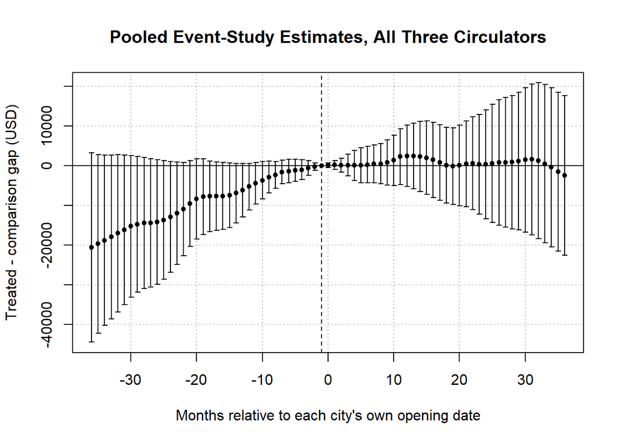

```r
pooled_es <- feols(HomeValue ~ i(event_month, treated, ref = -1) | zip_id + city^event_month,
                    cluster = ~zip_id, data = pooled_panel)
iplot(pooled_es,
      main = "Pooled Event-Study Estimates, All Three Circulators",
      xlab = "Months relative to each city's own opening date", ylab = "Treated - comparison gap (USD)")
```

### Diagnostic: which city is driving the pre-trend?

Splitting the event study out by city (still each against its own comparison group, no pooling) should show whether the drift is broad-based or concentrated in the two less-vetted cities.

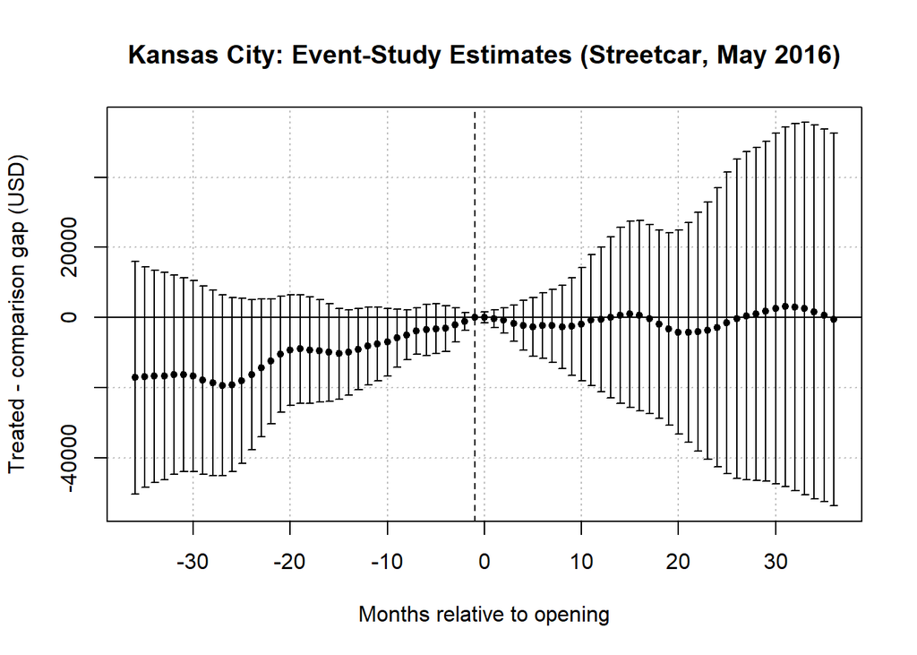

```r
kc_es <- feols(HomeValue ~ i(event_month, treated, ref = -1) | RegionName + Date,
               cluster = ~RegionName, data = kc_panel)
iplot(kc_es, main = "Kansas City: Event-Study Estimates (Streetcar, May 2016)",
      xlab = "Months relative to opening", ylab = "Treated - comparison gap (USD)")
```

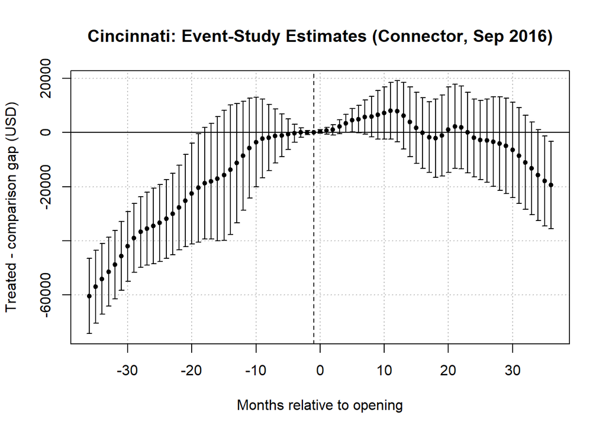

```r
cincy_es <- feols(HomeValue ~ i(event_month, treated, ref = -1) | RegionName + Date,
                   cluster = ~RegionName, data = cincy_panel)
iplot(cincy_es, main = "Cincinnati: Event-Study Estimates (Connector, Sep 2016)",
      xlab = "Months relative to opening", ylab = "Treated - comparison gap (USD)")
```

One caution on interpretation: this 36-month pre-window can’t actually adjudicate whether that drift is anticipation or an older, independent trend. It runs from roughly September 2013 to the Connector’s September 2016 opening – which is close to when the project’s funding was locked in and construction became real, not some arbitrary earlier cutoff. That means every point in this window already sits inside the “this is happening” era; there’s no flat, pre-momentum baseline here to compare against. A drift that starts right when the window starts is equally consistent with (a) anticipation of a now-credible project and (b) an independent trend that predates the window entirely and simply continued through it. Telling those apart would need a longer pre-period reaching back before the project had real momentum (roughly 2009-2011): a gap that’s already wide back then points to (b); one that’s flat until momentum picks up around 2013 is more consistent with (a). That check isn’t run here, but the data to run it exists.

Priors still lean toward (b), for what it’s worth: a streetcar/circulator isn’t the kind of large capital project (a new subway line, say) that real estate markets are known to price in years ahead of completion, and downtown/Over-the-Rhine was independently one of Cincinnati’s most visible revitalization stories of the decade regardless of the Connector.

What the data says more cleanly, without needing to settle that question: the post-opening coefficients show no additional departure from wherever the pre-existing trend already had prices headed. Whatever was moving 45202’s home values before September 2016 – neighborhood revival, anticipation, or both – the Connector’s actual opening doesn’t appear to have added anything on top of it. Same pattern, more mildly, in Kansas City. A combined quarter-billion dollars in construction cost across these two projects showing no detectable marginal effect on the home values they were partly justified by is worth sitting with on its own, independent of how the pre-trend itself is explained.

## Discussion

A few limitations worth stating plainly rather than glossing over:

- **The pooled model fails its own parallel-trends check, and Cincinnati is why.** The per-city diagnostic traces the pooled pre-trend almost entirely to Cincinnati (a ~$60k pre-period gap closing smoothly to zero right at the Connector’s opening), with a milder echo in Kansas City; St. Louis alone is comparatively flat. That undercuts the pooled DiD estimate ($9,735, not significant at conventional levels anyway) as evidence of a real circulator effect – it looks much more like 45202 (downtown/Over-the-Rhine) riding Cincinnati’s broader, independent 2010s revitalization wave, which plausibly helped motivate building the Connector there in the first place rather than resulting from it. This is arguably the most useful finding in this document: not a headline effect size, but a demonstration of why checking parallel trends explicitly (rather than eyeballing a line chart, as the original paper did) matters – a naive two-period DiD would have reported the $9,735 figure with no way to know it was confounded, and would have had no way to catch that Cincinnati’s own treated zip was already moving well before treatment.
- **Small N.** Even pooled, this is 6 treated zips and 10 comparison zips across three cities – still a small sample for a panel regression, and results will be sensitive to exactly which zips are in each group.
- **Comparison-zip vetting is uneven, but a better comparison group likely wouldn’t fully fix Cincinnati.** St. Louis’s group has a real argument behind it; Kansas City’s and Cincinnati’s had a one-pass county-level check. That’s worth fixing regardless, but Cincinnati’s problem looks more like treatment-placement (the treated zip itself was already on a different trajectory) than a fixable comparison-zip mismatch alone.
- **Pooling assumes a common effect.** A heritage trolley, a modern streetcar, and a rebranded circulator bus are not the same intervention, and St. Louis/Kansas City/Cincinnati are not the same housing market. The pooled estimate is an average effect across three genuinely different cases, which is a real assumption, not a neutral default.
- **This is not the “stacked DiD” of Cengiz et al. (2019) in the strict sense** – that design exists to handle a shared pool of control units reused across staggered treatment cohorts, which isn’t the situation here since each city’s units are entirely its own. Worth being precise about that distinction rather than borrowing the name without the matching problem.

## Conclusion: was it worth it?

I want to be upfront that this section is opinion, not something the regression itself proves – but it’s the opinion this analysis leaves me with, and I think it’s worth stating plainly rather than hiding behind hedged academic language.

None of these three projects shows a statistically detectable increase in nearby home values, and where there’s a large-looking pre/post gap (Cincinnati, mildly Kansas City), the evidence points to a pre-existing trend the project didn’t add to, not an effect of the project itself. That’s one of the two headline justifications these projects are usually sold on – the other being ridership, i.e., actual transportation utility – and on that count the picture is mixed but not encouraging for two of the three:

- **St. Louis’s Delmar Loop Trolley** ($51M to build) carried roughly 12,000 riders across its entire 2024 season – less than a single week’s ridership on MetroBus’s busiest route ([KMOV, Nov. 2024](https://www.firstalert4.com/2024/11/11/loop-trolley-ends-season-operating-within-budget-with-44-percent-increase-ridership/); MetroBus systemwide ridership).
- **The Cincinnati Bell Connector** ($148M) hit a record ~1.2 million riders in 2024 (~3,300/day averaged across the year), but SORTA’s single busiest bus route alone carries roughly 9,700 weekday boardings – more than double the streetcar’s daily average across its whole loop (Connector ridership).
- **The KC Streetcar** ($102M for the original starter line) actually complicates this story: 2025 ridership (~2.16 million/year, ~5,900/day) now exceeds a comparable busy RideKC bus route on a per-day basis ([KC Streetcar ridership](https://en.wikipedia.org/wiki/KC_Streetcar)). By raw ridership, it’s a genuine transit success relative to St. Louis and Cincinnati – but matching a bus route’s ridership at roughly $46M/mile (and a since-built extension north of $100M/mile) only pencils out as a good use of money if there’s something *besides* moving the same number of people a bus already moves – the usual pitch being exactly the property-value uplift this analysis is built to detect. That uplift isn’t there for KC either. Good ridership without a value externality just means you paid a rail premium for what a bus route already does.

So the ridership case for calling these “real transit” rather than a civic amenity is weak for St. Louis and Cincinnati, mixed-to-positive for Kansas City. But the property-value case – tested directly here – comes back null for all three, including Kansas City. If a marginal transit dollar is supposed to either move people or move property values, and a combined several hundred million dollars across these three projects didn’t clearly do either relative to just running more buses on routes that already carry many times the ridership, that’s a real strike against how that money was spent, not just an academic null result to shrug off. I’d rather see that dollar go toward frequency and coverage on the bus network already doing the actual work of moving people in these cities.

(Ridership and cost figures above are from Wikipedia’s sourced ridership tables and local news coverage, current as of late 2025/2025-season reporting where available; route-level bus comparisons in particular are order-of-magnitude estimates from secondary sources and are worth a final check against each transit agency’s own published ridership reports before this goes out publicly.)

## Note on results

This notebook has been rendered and reviewed – see the Conclusion above for the headline takeaway, and the per-city diagnostic in Part 2 for why the pooled coefficient shouldn’t be read at face value. If the underlying zip lists, windows, or opening dates change later, re-check the event-study plots for new pre-trend issues before trusting any point estimate that comes out of a re-render; a clean-looking coefficient table next to a sloped pre-trend plot is exactly the failure mode this document was built to catch.